# Graphics Choices

Then continue …

… but not before you’ve written down your opinions …

… Really!

… Are you ready now?

… You’ve really written something?

… Then go on.

There are several bad features of this plot:

- Too much ink.
- The order of the levels of `tissue` is alphabetical. It’s unlikely that the mechanisms of cancer consider what we call different types of cancer in English. So the x-axis order is being wasted.
- The precision of the feature (mean expression) is not shown. How would the viewer know whether this spread is just the result of random variation?

Here are several suggestions for improving the graphic:

1. Lighten up on the color. Perhaps `alpha=.2`. Or perhaps a dot plot rather than a bar chart.
2. Reorder the tissue types.

   One way to do this is to pick a quantity that you want to dictate the order of groups. For instance, the mean expression.
   - Create a data table of that quantity for each group (as with `SimpleStats`).
   - Reorder the categories based on the quantity:

     ```r
     SimpleStats2 <-
       SimpleStats %>%
       mutate( tissue=reorder( tissue, mid ) )
     ```

     Use `disc()` to order the other way.
3. Show a statistical measure of the variation.

   Without going into details of statistical method, a very common way to present the imprecision in an estimated quantity is with a “standard error.” For quantities such as the mean, the standard error has a simple form (but not necessarily a form that will be obvious to you). Here’s the calculation:

   ```r
   SimpleStats3 <-
     MyProbe %>%
     group_by( tissue ) %>%
     summarise( mid=mean( expression ),
            se=sd(expression)/sqrt(n()) )
   ```

4. Show the expression values for individual cases.
5. Use a different modality, e.g. a dot plot, a box-and-whiskers plot (with `notch=TRUE`).

The conventional solution is not the best: show the bars along with the measure of precision.

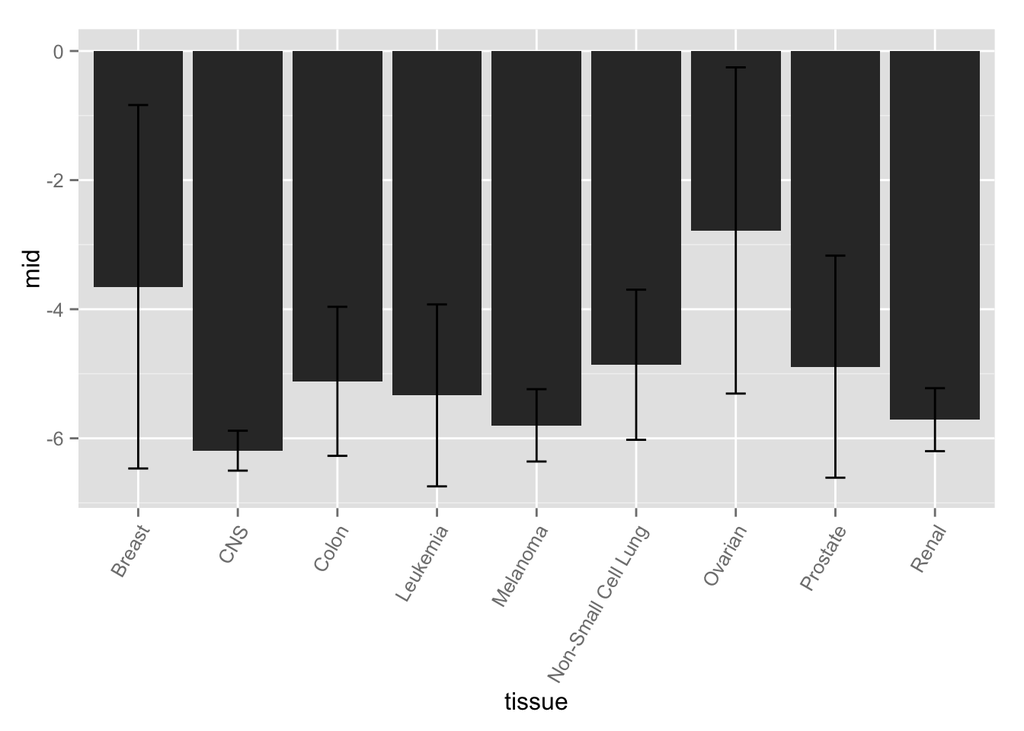

Statisticians refer to such things as “dynamite plots,” in a way intended to be pejorative. You can find a better way to present these data.

## Explication of the Data Transfiguration

The `NCI60` table is in wide format: each of the cell lines is its own variable. You’re going to turn it into a narrow format.

1. Look at the variable names in `NCI60`. How many are there?
2. Run this command:

   ```r
   Narrow <-
     NCI60 %>%
     gather( cellLine, expression, -Probe ) %>%
     mutate( cellLine=as.character(cellLine) )
   ```

Look at a small random set of the cases in `Narrow`. How many variables are there now?

Add in the cell types (with some technical corrections to make names match)

```r
JustTheTypes <-
  NCI60cells %>%
  mutate( cellLine=as.character(cellLine) ) %>%
  mutate( cellLine=gsub("\\:",".", cellLine)) %>%
  select(cellLine, tissue )
```

Now, add the kind of cell line the each case belongs to. This information is in the `NCI60cells` table. The variables already have matching names.

```r
Narrow <- inner_join( Narrow, JustTheTypes )
```

Pick one of these probes to look at, it doesn’t matter which one.[^3] A_32_P33263 CP FSD1 A_32_P52227 A_23_P135646 FLJ38359 ZNF682 A_24_P936145 ALS2CR4 DZIP1L LOC492303 ZNF277P CBFA2T3 MUC13 A_32_P168727

```
##         Probe      cellLine expression tissue
## 1 A_32_P33263       BR.MCF7      -1.58 Breast
## 2 A_32_P33263 BR.MDA_MB_231      -5.47 Breast
## 3 A_32_P33263     BR.HS578T      -6.18 Breast
## 4 A_32_P33263     BR.BT_549      -5.91 Breast
```

Now, `MyProbe` will look like this:

```
##         Probe      cellLine expression tissue
## 1 A_32_P33263       BR.MCF7      -1.58 Breast
## 2 A_32_P33263 BR.MDA_MB_231      -5.47 Breast
## 3 A_32_P33263     BR.HS578T      -6.18 Breast
```

[^1]: `NCI60` and `NCI60cells` are lightly re-organized from the [form provided by Staunton *et al.*](http://www.broadinstitute.org/mpr/NCI60/NCI60.html).
[^2]: A few lines involve data cleaning, which you have not yet studied. Don’t worry about the lines where `as.character()` or `gsub()` appear.
[^3]: In reality, the choice of probe makes a great deal of difference. These particularly probes were chosen based on a screening test. In an upcoming part of the course, you’ll look at how to deal with multiple variables, such as the 41,078 variables here.